# Capstone Exploratory Data Analysis and Modeling Report

Preetam Balijepalli

September 5, 2016

# Synopsis

The goal of this project is just to display that we have gotten used to working with the data and that we are on track to create your prediction algorithm. Need to:

1. Demonstrate that we have downloaded the data and have successfully loaded it in.
2. Create a basic report of summary statistics about the data sets.
3. Report any interesting findings that we have amassed so far.
4. Get feedback on the plans for creating a prediction algorithm and Shiny app.

The text documents are provided from different three web sources: blogs, twitter and news articles. This report demonstrates the preliminary exploration of the data and the possible ways to build the prediction algorithm.

# Analysis Methodology

# Results

# Exploratory Analisys

## Libraries

Libraries used in this study.

```r
library(tm,quietly = TRUE, warn.conflicts = FALSE)
library(NLP,quietly = TRUE, warn.conflicts = FALSE)
library(RWeka,quietly = TRUE, warn.conflicts = FALSE)
library(stringi,quietly = TRUE, warn.conflicts = FALSE)
library(ggplot2,quietly = TRUE, warn.conflicts = FALSE)
library(dplyr,quietly = TRUE, warn.conflicts = FALSE)
library(SnowballC,quietly = TRUE, warn.conflicts = FALSE)
library(wordcloud,quietly = TRUE, warn.conflicts = FALSE)
library(fpc,quietly = TRUE, warn.conflicts = FALSE)
library(qdap,quietly = TRUE, warn.conflicts = FALSE)
```

## Load Data

Once loading library is, we can go ahead and read in the text files.

```r
blogs <- readLines("D:/Coursera-SwiftKey/final/en_US/en_US.blogs.txt", encoding = "UTF-8", skipNul = TRUE)

news <- readLines("D:/Coursera-SwiftKey/final/en_US/en_US.news.txt", encoding = "UTF-8", skipNul = TRUE)
twitter <- readLines("D:/Coursera-SwiftKey/final/en_US/en_US.twitter.txt", encoding = "UTF-8", skipNul = TRUE)
```

Verify the number of rows and Characters

```r
#Number of rows
numrows.blogs <- NROW(blogs)
numrows.news <- NROW(news)
numrows.twitter <- NROW(twitter)
```

```r
#Number of characters
numchars.blogs <- sum(nchar(blogs))
numchars.news <- sum(nchar(news))
numchars.twitter <- sum(nchar(twitter))
```

## Creating Corpus

Since the data is huge loading some sample data to create corpus

```r
#Number of rows
thousandrows.blogs <- readLines("D:/Coursera-SwiftKey/final/en_US/en_US.blogs.txt", 1000,encoding = "latin1",warn = FALSE)
thousandrows.news <- readLines("D:/Coursera-SwiftKey/final/en_US/en_US.news.txt", 1000,encoding = "latin1", warn = FALSE)
thousandrows.twitter <- readLines("D:/Coursera-SwiftKey/final/en_US/en_US.twitter.txt", 1000,encoding = "latin1", warn = FALSE)

#Validating the number of rows loaded
count.thousandrows.blogs <- NROW(thousandrows.blogs)
count.thousandrows.news <- NROW(thousandrows.news)
count.thousandrows.twitter <- NROW(thousandrows.twitter)

#Validating the number of characters
count.thousandchars.blogs <- sum(nchar(thousandrows.blogs))
count.thousandchars.news <- sum(nchar(thousandrows.news))
count.thousandchars.twitter <- sum(nchar(thousandrows.twitter))


#Corpus is really just a character vector with some extra attributes. So it's best to convert it to character than you can save that to a data.frame

allfilestmp <- c(thousandrows.blogs,thousandrows.news,thousandrows.twitter)
allfiles <- paste(allfilestmp, collapse = " ")

## Create corpus object
require(tm)
vector.source <- VectorSource(allfiles)
corpus <- Corpus(x=vector.source)

# Clean corupus
corpus <- tm_map(corpus, removePunctuation)
corpus <- tm_map(corpus, removeNumbers)
corpus <- tm_map(corpus, stripWhitespace)
corpus <- tm_map(corpus, tolower)
corpus <- tm_map(corpus, stemDocument)
corpus <- tm_map(corpus, removeWords, stopwords("english"))
corpus <- tm_map(corpus, PlainTextDocument)

#Validating the Corpus (with sample data before pre-processing)
inspect(corpus)
```

```
## <<VCorpus>>
## Metadata:  corpus specific: 0, document level (indexed): 0
## Content:  documents: 1
##
## [[1]]
## <<PlainTextDocument>>
## Metadata:  7
## Content:  chars: 375233
```

## Tokenize and Calculate Frequencies of N-Grams

Using RWeka package to construct functions that tokenize the sample and construct matrices of uniqrams, bigrams, and trigrams.

```r
unigram.tokenizer <- function(x) NGramTokenizer(x, Weka_control(min = 1, max = 1))
bigram.tokenizer <- function(x) NGramTokenizer(x, Weka_control(min = 2, max = 2))
trigram.tokenizer <- function(x) NGramTokenizer(x, Weka_control(min = 3, max = 3))

require(SnowballC)
unigram.matrix <- TermDocumentMatrix(corpus, control = list(tokenize = unigram.tokenizer))
bigram.matrix <- TermDocumentMatrix(corpus, control = list(tokenize = bigram.tokenizer))
trigram.matrix <- TermDocumentMatrix(corpus, control = list(tokenize = trigram.tokenizer))
```

Then we find the frequency of terms in each of these 3 matrices and construct dataframes of these frequencies.

```r
###Calculate frequency of n-grams
unigram.corpus <- findFreqTerms(unigram.matrix,lowfreq = 50)
bigram.corpus  <- findFreqTerms(bigram.matrix,lowfreq=50)
trigram.corpus <- findFreqTerms(trigram.matrix,lowfreq=50)

unigram.corpus.frequency <- rowSums(as.matrix(unigram.matrix[unigram.corpus,]))
bigram.corpus.frequency <- rowSums(as.matrix(bigram.matrix[bigram.corpus,]))
trigram.corpus.frequency <- rowSums(as.matrix(trigram.matrix[trigram.corpus,]))

unigram.corpus.frequency <- data.frame(word=names(unigram.corpus.frequency), frequency=unigram.corpus.frequency)
bigram.corpus.frequency <- data.frame(word=names(bigram.corpus.frequency), frequency=bigram.corpus.frequency)
trigram.corpus.frequency <- data.frame(word=names(trigram.corpus.frequency), frequency=trigram.corpus.frequency)
```

## Including Plots

### Unigram Word Frequency

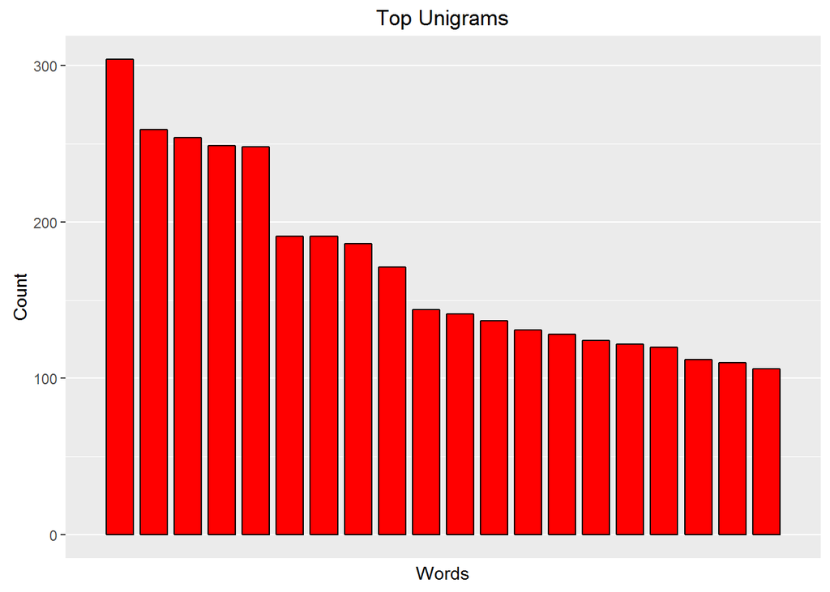

```r
plot_n_grams <- function(data, title, num) {
  df2 <- data[order(-data$frequency),][1:num,]
  ggplot(df2, aes(x = seq(1:num), y = frequency)) +
    geom_bar(stat = "identity", fill = "red", colour = "black", width = 0.80) +
    coord_cartesian(xlim = c(0, num+1)) +
    labs(title = title) +
    xlab("Words") +
    ylab("Count") +
    scale_x_discrete(breaks = seq(1, num, by = 1), labels = df2$word[1:num]) +
    theme(axis.text.x = element_text(angle = 90, hjust = 1))
}

plot_n_grams(unigram.corpus.frequency,"Top Unigrams",20)
```

[output not shown]

```r
require(quanteda)
unigram.corpus <- corpus(thousandrows.blogs)
bigram.corpus <- corpus(thousandrows.news)
trigram.corpus <- corpus(thousandrows.twitter)


corpus_sum <- unigram.corpus + bigram.corpus + trigram.corpus


document.frequency.matrix <- dfm(corpus_sum, verbose = TRUE, toLower = TRUE, removeTwitter = TRUE,
             removeNumbers = TRUE, ignoredFeatures = stopwords("english"))
```

```
## Creating a dfm from a corpus ...
```

```
##
##    ... lowercasing
```

```
##
##    ... tokenizing
```

```
##
##    ... indexing documents: 3,000 documents
```

```
##
##    ... indexing features:
```

```
## 14,261 feature types
```

```
## ...
```

```
## removed 165 features, from 174 supplied (glob) feature types
```

```
##    ... created a 3000 x 14097 sparse dfm
##    ... complete.
## Elapsed time: 0.45 seconds.
```

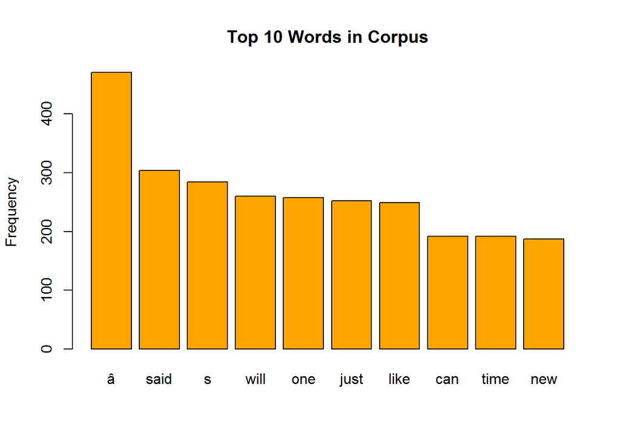

```r
barplot(topfeatures(document.frequency.matrix, 10), main="Top 10 Words in Corpus", col="orange", ylab="Frequency")
```

## Conclusion

Initial exploratory analysis is done next steps will be to build a predictive algorithm that uses an n-gram model with a frequency look up similar to the analysis above. This algorithm will then be deployed in a Shiny app and will suggest the most likely next word after a phrase is typed.